# Maternal Care Writeup

Analysis of juvenile survival

```r
library(tidyverse)
library(RMySQL)
library(lme4)
```

Here we will walk through the analysis.

## Data Preparation

In the `r_scripts/data-cleaning.R` file I fiiltered for juveniles and got rid of the individuals that were run a second time by April in 2017 and 2018. We then impute parturition dates using a simple model which can be found in `model-training.R`

```r
personality = read_csv('data/personality-mrw-imputed.csv', show_col_types = F)

glimpse(personality)
```

```
## Rows: 372
## Columns: 37
## $ squirrel_id      <dbl> 6317, 6367, 6416, 6419, 6423, 6456, 6472, 6483, 6492,…
## $ sex              <chr> "F", "F", "F", "M", "M", "F", "M", "M", "F", "M", "F"…
## $ year             <dbl> 2005, 2005, 2005, 2005, 2005, 2005, 2005, 2005, 2005,…
## $ observer         <chr> "AKB", "AKB", "AKB", "AKB", "AKB", "AKB", "AKB", "AKB…
## $ cohort           <dbl> 2005, 2005, 2005, 2005, 2005, 2005, 2005, 2005, 2005,…
## $ grid             <chr> "AG", "AG", "SU", "AG", "KL", "SU", "SU", "KL", "KL",…
## $ trialnumber      <dbl> 1, 1, 1, 1, 1, 1, 1, 1, 1, 1, 1, 1, 1, 1, 1, 1, 1, 1,…
## $ trialdate        <date> 2005-06-27, 2005-07-17, 2005-08-15, 2005-07-14, 2005…
## $ taglft           <chr> "44599", "46420", "46721", "43850", "46703", "46803",…
## $ tagrt            <chr> "44600", "46421", "46722", "43851", "46704", "46804",…
## $ colours          <chr> NA, NA, NA, NA, NA, NA, NA, NA, NA, NA, NA, NA, NA, N…
## $ walk             <dbl> 32.445, 25.245, 120.690, 42.615, 65.250, 121.500, 143…
## $ jump             <dbl> 3, 19, 90, 17, 21, 104, 110, 83, 91, 89, 75, 62, 75, …
```

[output cut: 24 more lines]

There are still some individuals who do not have part dates. Most of these are individuals who do not have litter ids.

If they do have litter ids then they dont have n1 dates or weights. These could probably be recovered using some fancy model that uses mating chase data, trapping data, etc but I don’t bother with that here.

```r
personality %>%
  filter(is.na(part)) %>%
  select(squirrel_id, year, litter_id, dam_id, n1_date)
```

```
## # A tibble: 31 × 5
##    squirrel_id  year litter_id dam_id n1_date
##          <dbl> <dbl>     <dbl>  <dbl>   <dbl>
##  1       11180  2005        NA     NA      NA
##  2       11180  2005        NA     NA      NA
##  3       12215  2012        NA     NA      NA
##  4       12215  2012        NA     NA      NA
##  5       13235  2012        NA     NA      NA
##  6       23256  2017        NA     NA      NA
##  7       23686  2018      8802  21895      NA
##  8       23788  2018        NA     NA      NA
##  9       23797  2018        NA     NA      NA
## 10       23856  2019        NA     NA      NA
## # … with 21 more rows
```

The next step is to include survival data to both the fall census and to 200 days. The data here can be generated with the `r_scripts/survival_data.R`.

## Data prep

First, we’ll get the variables in the right format for the analysis.

```r
personality = read_csv('data/personality-mrw-survival.csv', show_col_types = FALSE) %>%
  mutate(survival = as.integer(survived_200d)) %>%
  group_by(grid, year) %>%
  mutate(growth_sc = scale(growth, scale = T, center = T)[,1],
         part_sc = scale(part, scale = T, center = T)[,1]) %>%
  ungroup()
```

Now, well add the loadings for the principle components for aggression and activity

```r
aggression = personality %>%
  select(front, back, attack, attacklatency, approachlatency) %>%
  mutate(across(everything(), ~if_else(is.na(.x), median(.x, na.rm = TRUE), .x)))


activity = personality %>%
  select(walk, still, hang, jump, chew, hole) %>%
  mutate(across(everything(), ~if_else(is.na(.x), median(.x, na.rm = TRUE), .x)))

pca_agg = prcomp(aggression, scale = TRUE, center = TRUE)
mis1 = predict(pca_agg)[,1]

pca_act = prcomp(activity, scale = TRUE, center = TRUE)
oft1 = predict(pca_act)[,1]

personality$oft1 = unlist(oft1)
personality$mis1 = unlist(mis1)
```

Just to show the data we can plot it here. These are the two PCs with a 95% ellipse.

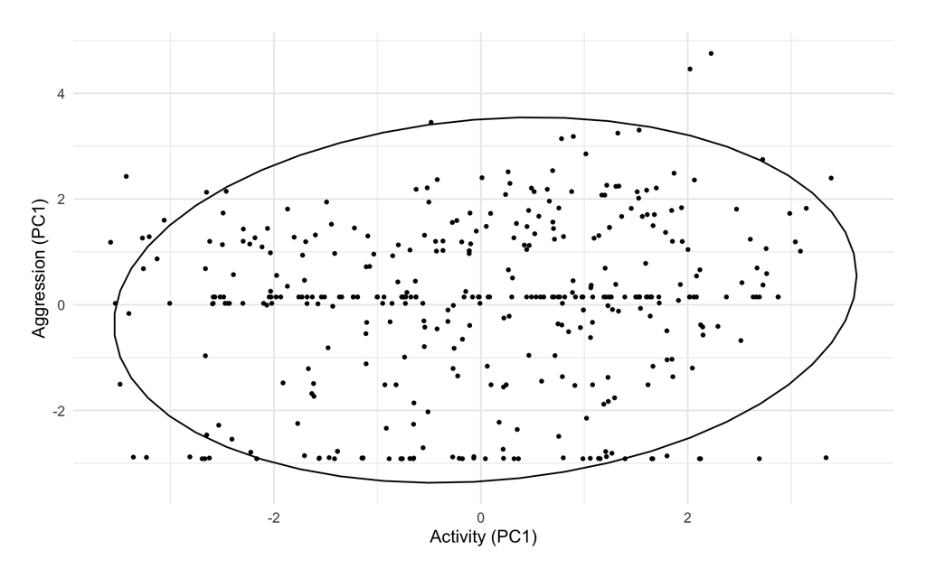

```r
ggplot(personality, aes(oft1, mis1)) +
  geom_point(size = 0.75) +
  stat_ellipse(level = 0.95) +
  labs(x = "Activity (PC1)", y = "Aggression (PC1)") +
  theme_minimal() +
  theme(plot.margin = margin(20,20,20,20))
```

## Survival to Fall Census

```r
dat1 = personality %>%
  mutate(across(c(year, dam_id, litter_id, grid), as_factor)) %>%
  filter(year != 2019,
         !if_any(c(survival, sex, age_at_trial, grid_density, growth_sc, part_sc, oft1, mis1, grid, year, dam_id, litter_id), .fns = is.na))

survival_to_autumn = glmer(made_it ~ sex +
                             scale(age_at_trial) +
                             part_sc*scale(grid_density) +
                             growth_sc*scale(grid_density) +
                             oft1*mis1*scale(grid_density) +
                             grid +
                             (1|year) +
                             (1|dam_id) +
                             (1|litter_id),
                           data = dat1,
                           na.action = 'na.omit',
                           family = binomial(link = "logit"),
                           control = glmerControl(optimizer = "bobyqa", optCtrl = list(maxfun = 1e8)))
```

```r
car::Anova(survival_to_autumn)
```

```
## Analysis of Deviance Table (Type II Wald chisquare tests)
##
## Response: made_it
##                                 Chisq Df Pr(>Chisq)
## sex                            3.4757  1  0.0622774 .
## scale(age_at_trial)           11.9597  1  0.0005436 ***
## part_sc                        3.0539  1  0.0805436 .
## scale(grid_density)            0.3822  1  0.5364069
## growth_sc                      0.3700  1  0.5429917
## oft1                           1.5696  1  0.2102707
## mis1                           3.7017  1  0.0543568 .
## grid                           7.9281  3  0.0475205 *
## part_sc:scale(grid_density)    1.1850  1  0.2763422
## scale(grid_density):growth_sc  1.5948  1  0.2066355
## oft1:mis1                      2.7616  1  0.0965517 .
## scale(grid_density):oft1       0.5684  1  0.4508936
## scale(grid_density):mis1       6.6225  1  0.0100698 *
## scale(grid_density):oft1:mis1  1.0990  1  0.2944898
## ---
## Signif. codes:  0 '***' 0.001 '**' 0.01 '*' 0.05 '.' 0.1 ' ' 1
```

First thing we see is that there is a singificant interaction between grid density and aggression as well as a nearly significant main effect of aggression, and a nearly significant interaction between aggression and activity.

## Survival to 200 days

```r
dat2 = personality %>%
  mutate(across(c(year, dam_id, litter_id, grid), as_factor)) %>%
  filter(!if_any(c(survival, sex, age_at_trial, grid_density, growth_sc, part_sc, oft1, mis1, grid, year, dam_id, litter_id), .fns = is.na))

survival_to_200d = glmer(survival ~ sex +
                             scale(age_at_trial) +
                             part_sc*scale(grid_density) +
                             growth_sc*scale(grid_density) +
                             oft1*mis1*scale(grid_density) +
                             grid +
                             (1|year) +
                             (1|dam_id) +
                             (1|litter_id),
                           data = dat2,
                           na.action = 'na.fail',
                           family = binomial(link = "logit"),
                           control = glmerControl(optimizer = "bobyqa", optCtrl = list(maxfun = 1e8)))
```

```r
car::Anova(survival_to_200d)
```

```
## Analysis of Deviance Table (Type II Wald chisquare tests)
##
## Response: survival
##                                Chisq Df Pr(>Chisq)
## sex                           4.1833  1    0.04082 *
## scale(age_at_trial)           0.2566  1    0.61246
## part_sc                       2.2897  1    0.13023
## scale(grid_density)           0.0867  1    0.76841
## growth_sc                     0.7935  1    0.37303
## oft1                          0.4518  1    0.50149
## mis1                          0.5596  1    0.45444
## grid                          6.2098  3    0.10184
## part_sc:scale(grid_density)   0.6953  1    0.40438
## scale(grid_density):growth_sc 1.3741  1    0.24110
## oft1:mis1                     1.1703  1    0.27934
## scale(grid_density):oft1      5.8744  1    0.01536 *
## scale(grid_density):mis1      0.5691  1    0.45061
## scale(grid_density):oft1:mis1 1.8063  1    0.17895
## ---
## Signif. codes:  0 '***' 0.001 '**' 0.01 '*' 0.05 '.' 0.1 ' ' 1
```

Here we see a significant effect of activity and density, as well as an effect of sex.

### Model effects

```r
summary(survival_to_autumn)
```

```
## Generalized linear mixed model fit by maximum likelihood (Laplace
##   Approximation) [glmerMod]
##  Family: binomial  ( logit )
## Formula: made_it ~ sex + scale(age_at_trial) + part_sc * scale(grid_density) +
##     growth_sc * scale(grid_density) + oft1 * mis1 * scale(grid_density) +
##     grid + (1 | year) + (1 | dam_id) + (1 | litter_id)
##    Data: dat1
## Control: glmerControl(optimizer = "bobyqa", optCtrl = list(maxfun = 1e+08))
##
##      AIC      BIC   logLik deviance df.resid
##    311.8    385.9   -135.9    271.8      280
##
## Scaled residuals:
##     Min      1Q  Median      3Q     Max
## -2.9343 -0.3442 -0.1129  0.3638  2.9430
##
## Random effects:
##  Groups    Name        Variance  Std.Dev.
##  litter_id (Intercept) 3.411e+00 1.847e+00
##  dam_id    (Intercept) 1.565e-10 1.251e-05
##  year      (Intercept) 1.525e+01 3.905e+00
## Number of obs: 300, groups:  litter_id, 145; dam_id, 136; year, 6
##
## Fixed effects:
##                                 Estimate Std. Error z value Pr(>|z|)
## (Intercept)                    -15.01457 9187.45258  -0.002 0.998696
## sexM                            -0.88011    0.47208  -1.864 0.062277 .
## scale(age_at_trial)              1.01148    0.29248   3.458 0.000544 ***
## part_sc                          0.43068    0.31027   1.388 0.165116
## scale(grid_density)              1.03281    1.07700   0.959 0.337576
## growth_sc                       -0.05131    0.28114  -0.182 0.855198
## oft1                             0.15544    0.16258   0.956 0.339033
## mis1                            -0.40772    0.18397  -2.216 0.026680 *
## gridSU                          13.40123 9187.45266   0.001 0.998836
## gridKL                          14.50288 9187.45253   0.002 0.998740
## gridJO                          11.56368 9187.45259   0.001 0.998996
## part_sc:scale(grid_density)      0.37827    0.34750   1.089 0.276342
## scale(grid_density):growth_sc   -0.37345    0.29572  -1.263 0.206636
## oft1:mis1                        0.14749    0.10357   1.424 0.154437
## scale(grid_density):oft1         0.09872    0.19473   0.507 0.612187
## scale(grid_density):mis1         0.56396    0.20306   2.777 0.005482 **
## scale(grid_density):oft1:mis1    0.11455    0.10927   1.048 0.294490
## ---
## Signif. codes:  0 '***' 0.001 '**' 0.01 '*' 0.05 '.' 0.1 ' ' 1
## optimizer (bobyqa) convergence code: 0 (OK)
## boundary (singular) fit: see help('isSingular')
```

So, we see males have lower survival survival than males

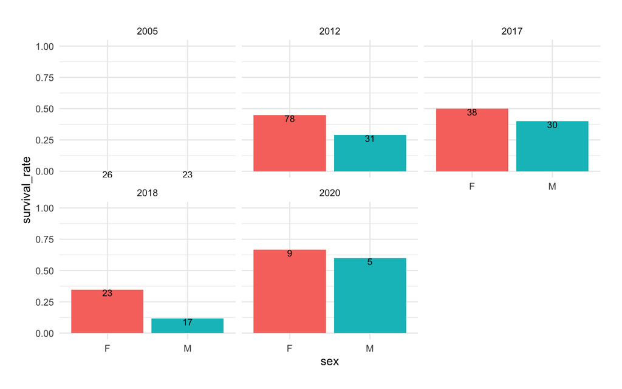

Next we see that aggression has a negative relationship with survival, with more aggressive individuals less likely to survive.

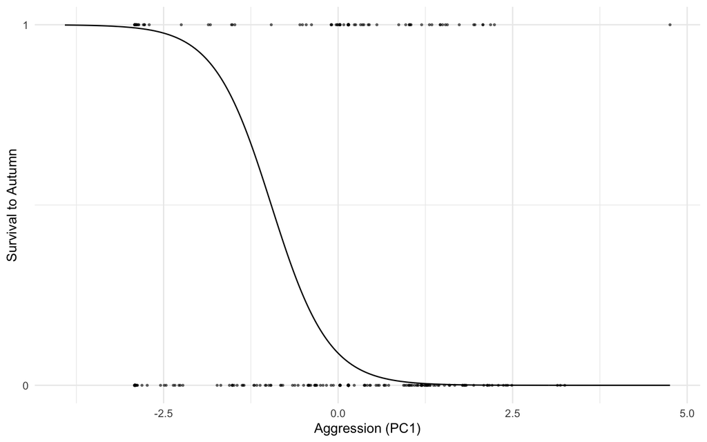

> This is a simplified plit that only accounts for a single level of sex and grid. However it captures the main effect

Finally, we have a significant interaction between grid density and aggression, where more aggressive individuals are more likely to survive to autumn under high densities.

> There is no good way to visualize this.

Here we look at individual’s link-predicted value of survival to autumn.

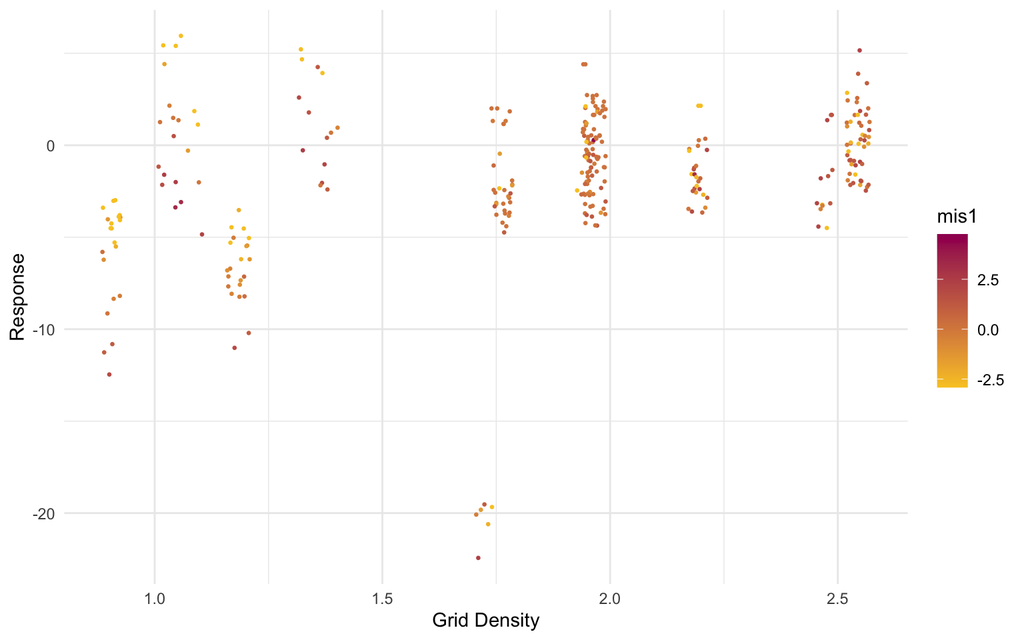

```r
summary(survival_to_200d)
```

```
## Generalized linear mixed model fit by maximum likelihood (Laplace
##   Approximation) [glmerMod]
##  Family: binomial  ( logit )
## Formula:
## survival ~ sex + scale(age_at_trial) + part_sc * scale(grid_density) +
##     growth_sc * scale(grid_density) + oft1 * mis1 * scale(grid_density) +
##     grid + (1 | year) + (1 | dam_id) + (1 | litter_id)
##    Data: dat2
## Control: glmerControl(optimizer = "bobyqa", optCtrl = list(maxfun = 1e+08))
##
##      AIC      BIC   logLik deviance df.resid
##    296.6    370.8   -128.3    256.6      282
##
## Scaled residuals:
##     Min      1Q  Median      3Q     Max
## -3.8412 -0.2607 -0.0563  0.2555  2.1409
##
## Random effects:
##  Groups    Name        Variance  Std.Dev.
##  litter_id (Intercept) 1.082e-13 3.290e-07
##  dam_id    (Intercept) 7.709e+00 2.777e+00
##  year      (Intercept) 3.642e+01 6.035e+00
## Number of obs: 302, groups:  litter_id, 146; dam_id, 137; year, 7
##
## Fixed effects:
##                               Estimate Std. Error z value Pr(>|z|)
## (Intercept)                   -7.98577    3.78166  -2.112   0.0347 *
## sexM                          -1.22879    0.60079  -2.045   0.0408 *
## scale(age_at_trial)            0.18425    0.36373   0.507   0.6125
## part_sc                       -0.66463    0.41869  -1.587   0.1124
## scale(grid_density)           -0.46340    1.18850  -0.390   0.6966
## growth_sc                     -0.30532    0.36627  -0.834   0.4045
## oft1                           0.03355    0.21468   0.156   0.8758
## mis1                          -0.29030    0.23832  -1.218   0.2232
## gridSU                         4.46444    2.86959   1.556   0.1198
## gridKL                         6.09275    2.87156   2.122   0.0339 *
## gridJO                         8.02175    3.50102   2.291   0.0219 *
## part_sc:scale(grid_density)    0.35680    0.42791   0.834   0.4044
## scale(grid_density):growth_sc -0.43138    0.36800  -1.172   0.2411
## oft1:mis1                      0.12468    0.13226   0.943   0.3458
## scale(grid_density):oft1       0.79085    0.31582   2.504   0.0123 *
## scale(grid_density):mis1      -0.16880    0.22404  -0.753   0.4512
## scale(grid_density):oft1:mis1 -0.15542    0.11564  -1.344   0.1790
## ---
## Signif. codes:  0 '***' 0.001 '**' 0.01 '*' 0.05 '.' 0.1 ' ' 1
```

```
##
## Correlation matrix not shown by default, as p = 17 > 12.
## Use print(x, correlation=TRUE)  or
##     vcov(x)        if you need it
```

```
## optimizer (bobyqa) convergence code: 0 (OK)
## boundary (singular) fit: see help('isSingular')
```